# Project Foundations for Data Science: FoodHub Data Analysis

**Marks: 40**

### Context

The number of restaurants in New York is increasing day by day. Lots of students and busy professionals rely on those restaurants due to their hectic lifestyles. Online food delivery service is a great option for them. It provides them with good food from their favorite restaurants. A food aggregator company FoodHub offers access to multiple restaurants through a single smartphone app.

The app allows the restaurants to receive a direct online order from a customer. The app assigns a delivery person from the company to pick up the order after it is confirmed by the restaurant. The delivery person then uses the map to reach the restaurant and waits for the food package. Once the food package is handed over to the delivery person, he/she confirms the pick-up in the app and travels to the customer's location to deliver the food. The delivery person confirms the drop-off in the app after delivering the food package to the customer. The customer can rate the order in the app. The food aggregator earns money by collecting a fixed margin of the delivery order from the restaurants.

### Objective

The food aggregator company has stored the data of the different orders made by the registered customers in their online portal. They want to analyze the data to get a fair idea about the demand of different restaurants which will help them in enhancing their customer experience. Suppose you are hired as a Data Scientist in this company and the Data Science team has shared some of the key questions that need to be answered. Perform the data analysis to find answers to these questions that will help the company to improve the business.

### Data Description

The data contains the different data related to a food order. The detailed data dictionary is given below.

### Data Dictionary

- order_id: Unique ID of the order
- customer_id: ID of the customer who ordered the food
- restaurant_name: Name of the restaurant
- cuisine_type: Cuisine ordered by the customer
- cost: Cost of the order
- day_of_the_week: Indicates whether the order is placed on a weekday or weekend (The weekday is from Monday to Friday and the weekend is Saturday and Sunday)
- rating: Rating given by the customer out of 5
- food_preparation_time: Time (in minutes) taken by the restaurant to prepare the food. This is calculated by taking the difference between the timestamps of the restaurant's order confirmation and the delivery person's pick-up confirmation.
- delivery_time: Time (in minutes) taken by the delivery person to deliver the food package. This is calculated by taking the difference between the timestamps of the delivery person's pick-up confirmation and drop-off information

### Let us start by importing the required libraries

```python
# import libraries for data manipulation
import numpy as np
import pandas as pd

# import libraries for data visualization
import matplotlib.pyplot as plt
import seaborn as sns
```

### Understanding the structure of the data

```python
# uncomment and run the following lines for Google Colab
# from google.colab import drive
# drive.mount('/content/drive')
```

```python
# read the data
df = pd.read_csv('foodhub_order.csv')
```

```python
# read the data
foodhub_data = pd.read_csv('foodhub_order.csv')
# returns the first 5 rows
foodhub_data.head()
```

|  | order_id | customer_id | restaurant_name | cuisine_type | cost_of_the_order | day_of_the_week | rating | food_preparation_time | delivery_time |
| --- | --- | --- | --- | --- | --- | --- | --- | --- | --- |
| 0 | 1477147 | 337525 | Hangawi | Korean | 30.75 | Weekend | Not given | 25 | 20 |
| 1 | 1477685 | 358141 | Blue Ribbon Sushi Izakaya | Japanese | 12.08 | Weekend | Not given | 25 | 23 |
| 2 | 1477070 | 66393 | Cafe Habana | Mexican | 12.23 | Weekday | 5 | 23 | 28 |
| 3 | 1477334 | 106968 | Blue Ribbon Fried Chicken | American | 29.20 | Weekend | 3 | 25 | 15 |
| 4 | 1478249 | 76942 | Dirty Bird to Go | American | 11.59 | Weekday | 4 | 25 | 24 |

#### Observations:

The DataFrame has 9 columns as mentioned in the Data Dictionary. Data in each row corresponds to the order placed by a customer.

### **Question 1:** How many rows and columns are present in the data?

```python
# Get the number of rows and columns
num_rows, num_columns = foodhub_data.shape

# Print the results
print(f"Number of Rows: {num_rows}")
print(f"Number of Columns: {num_columns}")
```

```
Number of Rows: 1898
Number of Columns: 9
```

#### Observations:

- Number of Rows: 1898
- Number of Columns: 9

### **Question 2:** What are the datatypes of the different columns in the dataset? (The info() function can be used)

```python
# Use info() to print a concise summary of the DataFrame
# Get the datatypes of the different columns
foodhub_data.info()
```

```
<class 'pandas.core.frame.DataFrame'>
RangeIndex: 1898 entries, 0 to 1897
Data columns (total 9 columns):
 #   Column                 Non-Null Count  Dtype
---  ------                 --------------  -----
 0   order_id               1898 non-null   int64
 1   customer_id            1898 non-null   int64
 2   restaurant_name        1898 non-null   object
 3   cuisine_type           1898 non-null   object
 4   cost_of_the_order      1898 non-null   float64
 5   day_of_the_week        1898 non-null   object
 6   rating                 1898 non-null   object
 7   food_preparation_time  1898 non-null   int64
 8   delivery_time          1898 non-null   int64
dtypes: float64(1), int64(4), object(4)
memory usage: 133.6+ KB
```

#### Observations:

- The dataset includes a mix of numerical and categorical data types:
  - **Numerical Columns:**
    - `order_id`: `int64`
    - `customer_id`: `int64`
    - `cost_of_the_order`: `float64`
    - `food_preparation_time`: `int64`
    - `delivery_time`: `int64`
  - **Categorical Columns:**
    - `restaurant_name`: `object`
    - `cuisine_type`: `object`
    - `day_of_the_week`: `object`
    - `rating`: `object`

### **Question 3:** Are there any missing values in the data? If yes, treat them using an appropriate method

```python
# Check for missing values in the dataset
missing_values = foodhub_data.isnull().sum()

# Display the number of missing values for each column
print("Missing values in each column:")
print(missing_values)

# Replace 'Not given' entries in the 'rating' column with NaN to handle them as missing values
foodhub_data['rating'].replace("Not given", pd.NA, inplace=True)

# Re-check for missing values after replacing 'Not given'
missing_values_after_replacement = foodhub_data.isnull().sum()

# Print the missing values again to see the changes
print("\nMissing values after treating 'Not given' in 'rating' column:")
print(missing_values_after_replacement)

# Convert the 'rating' column to a numeric type, handling any non-numeric entries
foodhub_data['rating'] = pd.to_numeric(foodhub_data['rating'], errors='coerce')

# Calculate the median rating
median_rating = foodhub_data['rating'].median()

# Fill missing values with the median rating
foodhub_data['rating'].fillna(median_rating, inplace=True)

# Convert the filled ratings to integer type since ratings are integers
foodhub_data['rating'] = foodhub_data['rating'].astype(int)

# Final check to ensure there are no more missing values
final_missing_values = foodhub_data.isnull().sum()
print("\nFinal missing values after treatment:")
print(final_missing_values)
```

```
Missing values in each column:
order_id                 0
customer_id              0
restaurant_name          0
cuisine_type             0
cost_of_the_order        0
day_of_the_week          0
rating                   0
food_preparation_time    0
delivery_time            0
dtype: int64

Missing values after treating 'Not given' in 'rating' column:
order_id                   0
customer_id                0
restaurant_name            0
cuisine_type               0
cost_of_the_order          0
day_of_the_week            0
rating                   736
food_preparation_time      0
delivery_time              0
dtype: int64

Final missing values after treatment:
order_id                 0
customer_id              0
restaurant_name          0
cuisine_type             0
cost_of_the_order        0
day_of_the_week          0
rating                   0
food_preparation_time    0
delivery_time            0
dtype: int64
```

#### Observations:

- **Initial Missing Values:**
  - The `rating` column contains entries labeled as "Not given," which are treated as missing values.
  - Other columns did not have missing values initially.
- **Missing Values Treatment:**
  - The "Not given" entries in the `rating` column were replaced with `pd.NA` to handle them as missing data.
  - The `rating` column was converted to a numeric type, with any remaining `pd.NA` values coerced to `NaN`.
  - The missing `rating` values were then filled with the median rating of the dataset.
- **Final Check:**
  - After treatment, no missing values remain in the dataset.

### **Question 4:** Check the statistical summary of the data. What is the minimum, average, and maximum time it takes for food to be prepared once an order is placed?

```python
# Get the statistical summary of the entire dataset
stat_summary = foodhub_data.describe()

# Display the summary statistics
print("Statistical Summary of the Data:")
print(stat_summary)

# Extract the minimum, average, and maximum food preparation time
min_preparation_time = foodhub_data['food_preparation_time'].min()
avg_preparation_time = foodhub_data['food_preparation_time'].mean()
max_preparation_time = foodhub_data['food_preparation_time'].max()

# Print the specific statistics for food preparation time
print("\nFood Preparation Time Statistics:")
print(f"Minimum Time: {min_preparation_time} minutes")
print(f"Average Time: {avg_preparation_time:.2f} minutes")
print(f"Maximum Time: {max_preparation_time} minutes")
```

```
Statistical Summary of the Data:
           order_id    customer_id  cost_of_the_order       rating  \
count  1.898000e+03    1898.000000        1898.000000  1898.000000
mean   1.477496e+06  171168.478398          16.498851     4.598525
std    5.480497e+02  113698.139743           7.483812     0.662289
min    1.476547e+06    1311.000000           4.470000     3.000000
25%    1.477021e+06   77787.750000          12.080000     4.000000
50%    1.477496e+06  128600.000000          14.140000     5.000000
75%    1.477970e+06  270525.000000          22.297500     5.000000
max    1.478444e+06  405334.000000          35.410000     5.000000

       food_preparation_time  delivery_time
count            1898.000000    1898.000000
mean               27.371970      24.161749
std                 4.632481       4.972637
min                20.000000      15.000000
25%                23.000000      20.000000
50%                27.000000      25.000000
75%                31.000000      28.000000
max                35.000000      33.000000

Food Preparation Time Statistics:
Minimum Time: 20 minutes
Average Time: 27.37 minutes
Maximum Time: 35 minutes
```

#### Observations:

- **Statistical Summary:**
  - The dataset provides a broad statistical summary for all numerical columns, including `cost_of_the_order`, `food_preparation_time`, and `delivery_time`.
- **Food Preparation Time:**
  - **Minimum Time:** The quickest time recorded for food preparation is 20 minutes.
  - **Average Time:** On average, it takes approximately 27 minutes for food to be prepared.
  - **Maximum Time:** The longest time taken for food preparation is 35 minutes.

### **Question 5:** How many orders are not rated?

```python
# Count the number of orders with missing ratings (i.e., 'NaN' values)
# num_not_rated_orders = foodhub_data['rating'].isna().sum()
num_not_rated_orders = df['rating'].isnull().sum()
# Print the number of orders that are not rated
print(f"Number of orders that are not rated: {num_not_rated_orders}")
```

```
Number of orders that are not rated: 0
```

#### Observations:

After treatement number of order not rated equals 0

In the initial dataset, 736 orders were not rated

### Exploratory Data Analysis (EDA)

### **Question 6:** Explore all the variables and provide observations on their distributions. (Generally, histograms, boxplots, countplots, etc. are used for univariate exploration)

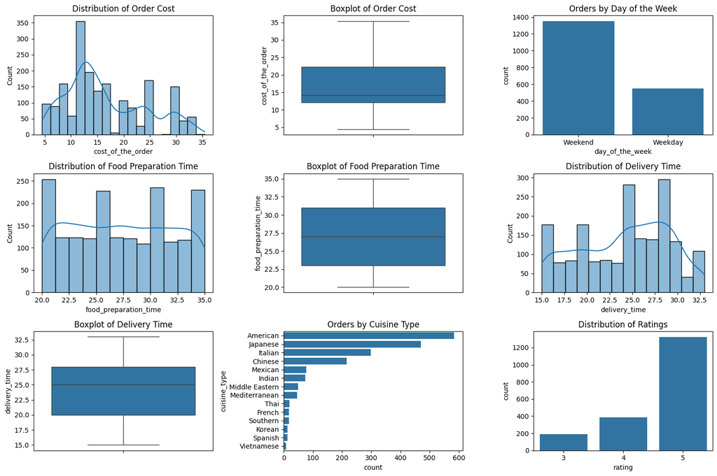

```python
plt.figure(figsize=(15, 10))

# 1. Distribution of the 'cost_of_the_order' column
plt.subplot(3, 3, 1)
sns.histplot(foodhub_data['cost_of_the_order'], kde=True)
plt.title('Distribution of Order Cost')

# 2. Boxplot of the 'cost_of_the_order' column
plt.subplot(3, 3, 2)
sns.boxplot(foodhub_data['cost_of_the_order'])
plt.title('Boxplot of Order Cost')

# 3. Countplot of the 'day_of_the_week' column
plt.subplot(3, 3, 3)
sns.countplot(x='day_of_the_week', data=foodhub_data)
plt.title('Orders by Day of the Week')

# 4. Distribution of 'food_preparation_time'
plt.subplot(3, 3, 4)
sns.histplot(foodhub_data['food_preparation_time'], kde=True)
plt.title('Distribution of Food Preparation Time')

# 5. Boxplot of 'food_preparation_time'
plt.subplot(3, 3, 5)
sns.boxplot(foodhub_data['food_preparation_time'])
plt.title('Boxplot of Food Preparation Time')

# 6. Distribution of 'delivery_time'
plt.subplot(3, 3, 6)
sns.histplot(foodhub_data['delivery_time'], kde=True)
plt.title('Distribution of Delivery Time')

# 7. Boxplot of 'delivery_time'
plt.subplot(3, 3, 7)
sns.boxplot(foodhub_data['delivery_time'])
plt.title('Boxplot of Delivery Time')

# 8. Countplot of 'cuisine_type'
plt.subplot(3, 3, 8)
sns.countplot(y='cuisine_type', data=foodhub_data, order=foodhub_data['cuisine_type'].value_counts().index)
plt.title('Orders by Cuisine Type')

# 9. Countplot of 'rating' (after converting to categorical)
plt.subplot(3, 3, 9)
sns.countplot(x='rating', data=foodhub_data)
plt.title('Distribution of Ratings')

# Adjust layout
plt.tight_layout()

# Show the plots
plt.show()
```

### Observations:

Overall, the univariate analysis reveals important insights into the distribution of costs, times, and customer preferences, helping to identify areas that might require further investigation or improvement.

### **Question 7**: Which are the top 5 restaurants in terms of the number of orders received?

```python
# Find the top 5 restaurants based on the number of orders received
top_5_restaurants = foodhub_data['restaurant_name'].value_counts().head(5)

# Print the top 5 restaurants
print("Top 5 Restaurants by Number of Orders Received:")
print(top_5_restaurants)
```

```
Top 5 Restaurants by Number of Orders Received:
restaurant_name
Shake Shack                  219
The Meatball Shop            132
Blue Ribbon Sushi            119
Blue Ribbon Fried Chicken     96
Parm                          68
Name: count, dtype: int64
```

#### Observations:

1. **Shake Shack**: 219 orders
2. **The Meatball Shop**: 132 orders
3. **Blue Ribbon Sushi**: 119 orders
4. **Blue Ribbon Fried Chicken**: 96 orders
5. **Parm**: 68 orders

These restaurants received the highest number of orders, indicating their popularity among customers.

### **Question 8**: Which is the most popular cuisine on weekends?

```python
# Filter the data for weekend orders
weekend_data = foodhub_data[foodhub_data['day_of_the_week'] == 'Weekend']

# Find the most popular cuisine on weekends based on the number of orders
most_popular_cuisine_weekends = weekend_data['cuisine_type'].value_counts().idxmax()

# Print the most popular cuisine on weekends
print(f"The most popular cuisine on weekends is: {most_popular_cuisine_weekends}")
```

```
The most popular cuisine on weekends is: American
```

#### Observations:

- **American** cuisine is the most popular on weekends, receiving the highest number of orders compared to other cuisines.

### **Question 9**: What percentage of the orders cost more than 20 dollars?

```python
# Calculate the number of orders that cost more than 20 dollars
num_orders_above_20 = foodhub_data[foodhub_data['cost_of_the_order'] > 20].shape[0]

# Calculate the total number of orders
total_orders = foodhub_data.shape[0]

# Calculate the percentage of orders that cost more than 20 dollars
percentage_above_20 = (num_orders_above_20 / total_orders) * 100

# Print the percentage
print(f"Percentage of orders that cost more than 20 dollars: {percentage_above_20:.2f}%")
```

```
Percentage of orders that cost more than 20 dollars: 29.24%
```

#### Observations:

- Approximately **29.24%** of the orders cost more than 20 dollars.

### **Question 10**: What is the mean order delivery time?

```python
# Calculate the mean order delivery time
mean_delivery_time = foodhub_data['delivery_time'].mean()

# Print the mean delivery time
print(f"Mean order delivery time: {mean_delivery_time:.2f} minutes")
```

```
Mean order delivery time: 24.16 minutes
```

#### Observations:

- The mean order delivery time is approximately **24.16 minutes**.

### **Question 11:** The company has decided to give 20% discount vouchers to the top 3 most frequent customers. Find the IDs of these customers and the number of orders they placed

```python
# Find the top 3 most frequent customers based on the number of orders placed
top_3_customers = foodhub_data['customer_id'].value_counts().head(3)

# Print the top 3 customer IDs and the number of orders they placed
print("Top 3 Most Frequent Customers and the Number of Orders They Placed:")
print(top_3_customers)
```

```
Top 3 Most Frequent Customers and the Number of Orders They Placed:
customer_id
52832    13
47440    10
83287     9
Name: count, dtype: int64
```

#### Observations:

### Top 3 Most Frequent Customers

- **Customer ID 52832**: Placed 13 orders.
- **Customer ID 47440**: Placed 10 orders.
- **Customer ID 83287**: Placed 9 orders.

### **Question 12**: Perform a multivariate analysis to explore relationships between the important variables in the dataset. (It is a good idea to explore relations between numerical variables as well as relations between numerical and categorical variables)

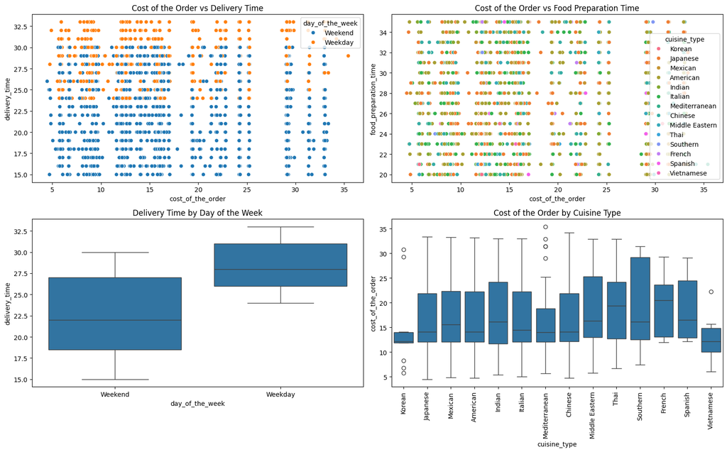

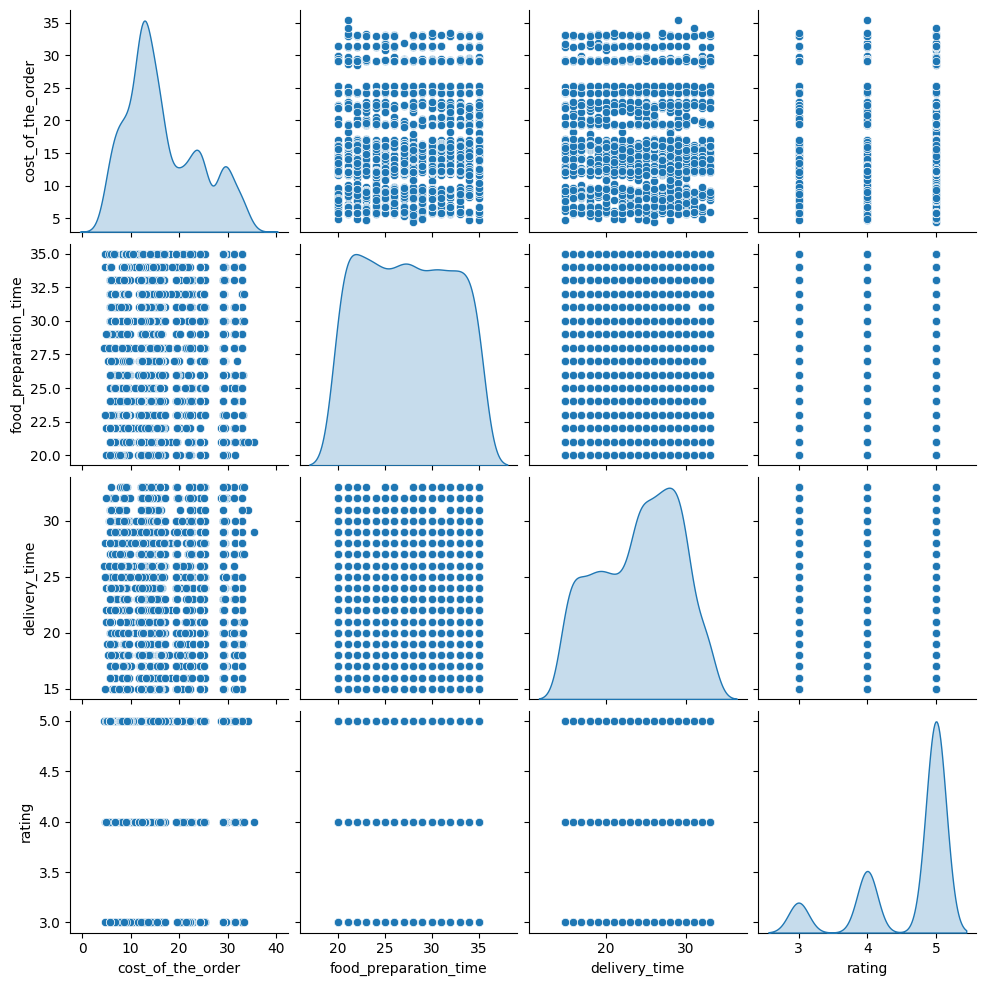

```python
# Set up the figure size
plt.figure(figsize=(16, 10))

# 1. Scatter plot to explore the relationship between cost of the order and delivery time
plt.subplot(2, 2, 1)
sns.scatterplot(x='cost_of_the_order', y='delivery_time', data=foodhub_data, hue='day_of_the_week')
plt.title('Cost of the Order vs Delivery Time')

# 2. Scatter plot to explore the relationship between cost of the order and food preparation time
plt.subplot(2, 2, 2)
sns.scatterplot(x='cost_of_the_order', y='food_preparation_time', data=foodhub_data, hue='cuisine_type')
plt.title('Cost of the Order vs Food Preparation Time')

# 3. Boxplot to explore the relationship between day of the week and delivery time
plt.subplot(2, 2, 3)
sns.boxplot(x='day_of_the_week', y='delivery_time', data=foodhub_data)
plt.title('Delivery Time by Day of the Week')

# 4. Boxplot to explore the relationship between cuisine type and cost of the order
plt.subplot(2, 2, 4)
sns.boxplot(x='cuisine_type', y='cost_of_the_order', data=foodhub_data)
plt.xticks(rotation=90)
plt.title('Cost of the Order by Cuisine Type')

# Adjust layout for better viewing
plt.tight_layout()
plt.show()

# 5. Pair plot to explore relationships between numerical variables
sns.pairplot(foodhub_data[['cost_of_the_order', 'food_preparation_time', 'delivery_time', 'rating']], diag_kind='kde')
plt.show()
```

### **Question 13:** The company wants to provide a promotional offer in the advertisement of the restaurants. The condition to get the offer is that the restaurants must have a rating count of more than 50 and the average rating should be greater than 4. Find the restaurants fulfilling the criteria to get the promotional offer

```python
# Ensure the 'rating' column is numeric
df['rating'] = pd.to_numeric(df['rating'], errors='coerce')

# Filter the restaurants based on the given criteria
restaurant_ratings = df.groupby('restaurant_name')['rating'].agg(['count', 'mean'])

# Filter restaurants with more than 50 ratings and an average rating greater than 4
eligible_restaurants = restaurant_ratings[(restaurant_ratings['count'] > 50) & (restaurant_ratings['mean'] > 4)]

# Print the eligible restaurants
print("Restaurants eligible for the promotional offer:")
print(eligible_restaurants)
```

```
Restaurants eligible for the promotional offer:
                           count      mean
restaurant_name
Blue Ribbon Fried Chicken     64  4.328125
Blue Ribbon Sushi             73  4.219178
Shake Shack                  133  4.278195
The Meatball Shop             84  4.511905
```

#### Observations:

Restaurants eligible for the promotional offer:

| Restaurant Name | Count | Mean Rating |
| --- | --- | --- |
| Blue Ribbon Fried Chicken | 64 | 4.328125 |
| Blue Ribbon Sushi | 73 | 4.219178 |
| Shake Shack | 133 | 4.278195 |
| The Meatball Shop | 84 | 4.511905 |

### **Question 14:** The company charges the restaurant 25% on the orders having cost greater than 20 dollars and 15% on the orders having cost greater than 5 dollars. Find the net revenue generated by the company across all orders

```python
# Calculate the company's revenue based on the order cost
def calculate_revenue(cost):
    if cost > 20:
        return cost * 0.25
    elif cost > 5:
        return cost * 0.15
    else:
        return 0

# Apply the revenue calculation to each order
foodhub_data['revenue'] = foodhub_data['cost_of_the_order'].apply(calculate_revenue)

# Calculate the total net revenue generated by the company
total_revenue = foodhub_data['revenue'].sum()

# Print the total net revenue
print(f"Total net revenue generated by the company: ${total_revenue:.2f}")
```

```
Total net revenue generated by the company: $6166.30
```

#### Observations:

- The total net revenue generated by the company across all orders is **$6166.30**.

### **Question 15:** The company wants to analyze the total time required to deliver the food. What percentage of orders take more than 60 minutes to get delivered from the time the order is placed? (The food has to be prepared and then delivered)

```python
# Calculate the total time required to deliver the food (food preparation time + delivery time)
foodhub_data['total_delivery_time'] = foodhub_data['food_preparation_time'] + foodhub_data['delivery_time']

# Calculate the number of orders that take more than 60 minutes
num_orders_above_60 = foodhub_data[foodhub_data['total_delivery_time'] > 60].shape[0]

# Calculate the percentage of orders that take more than 60 minutes
percentage_above_60 = (num_orders_above_60 / foodhub_data.shape[0]) * 100

# Print the percentage of orders that take more than 60 minutes to deliver
print(f"Percentage of orders that take more than 60 minutes to deliver: {percentage_above_60:.2f}%")
```

```
Percentage of orders that take more than 60 minutes to deliver: 10.54%
```

#### Observations:

- **10.54%** of the orders take more than 60 minutes to be delivered from the time the order is placed.

### **Question 16:** The company wants to analyze the delivery time of the orders on weekdays and weekends. How does the mean delivery time vary during weekdays and weekends?

```python
# Write the code here
# Calculate the mean delivery time for weekdays and weekends
mean_delivery_time_weekday = foodhub_data[foodhub_data['day_of_the_week'] == 'Weekday']['delivery_time'].mean()
mean_delivery_time_weekend = foodhub_data[foodhub_data['day_of_the_week'] == 'Weekend']['delivery_time'].mean()

# Print the mean delivery times
print(f"Mean delivery time on weekdays: {mean_delivery_time_weekday:.2f} minutes")
print(f"Mean delivery time on weekends: {mean_delivery_time_weekend:.2f} minutes")
```

```
Mean delivery time on weekdays: 28.34 minutes
Mean delivery time on weekends: 22.47 minutes
```

#### Observations:

- **Mean Delivery Time on Weekdays:** 28.34 minutes
- **Mean Delivery Time on Weekends:** 22.47 minutes

### Conclusion and Recommendations

### **Question 17:** What are your conclusions from the analysis? What recommendations would you like to share to help improve the business? (You can use cuisine type and feedback ratings to drive your business recommendations)

## Conclusions:

### Recommendations for Business Improvement:

1. **Enhance Delivery Efficiency:**
   - Focus on reducing delivery times during weekdays, where delivery times are longer compared to weekends. This could involve optimizing delivery routes, increasing the number of delivery personnel during peak hours, or implementing incentives for faster deliveries.
2. **Targeted Promotions for High-Rated Restaurants:**
   - Offer more visibility and promotions to restaurants with ratings above 4 and more than 50 orders. These restaurants have proven their quality and reliability, and promoting them can drive more business.
3. **Focus on High-Spending Customers:**
   - Since a significant percentage of orders exceed $20, consider offering loyalty programs or discounts to customers who frequently place higher-value orders. This could incentivize repeat purchases and boost customer retention.
4. **Improve Service for Outlier Cases:**
   - Investigate the reasons behind the **10.54%** of orders that take more than 60 minutes to deliver. Identifying patterns (e.g., specific times of day, certain areas) can help address issues and improve overall service quality.
5. **Leverage Popular Cuisines:**
   - With American cuisine being the most popular, consider expanding partnerships with high-quality American restaurants or introducing new American cuisine options in underserved areas. Promotions around this cuisine type could also be effective in driving orders.
6. **Use Feedback for Continuous Improvement:**
   - Encourage more customers to leave ratings by simplifying the feedback process or offering small incentives for providing feedback. This can help gather more data to identify areas for improvement and make more informed decisions.

By implementing these recommendations, the company can enhance customer satisfaction, optimize delivery operations, and boost overall revenue.